# O Pacote geobr

## Construindo um mapa o IDHM dos municípios de Mato Grosso do Sul

Inicialmente, vamos fazer a leitura dos dados

```r
library(readxl)
atlas2013_dadosbrutos_pt <- read_excel("dados/Atlas_2013_municipal_estadual_Brasil.xlsx",
    sheet = "MUN 91-00-10")
# reduzir linhas para 2010 e MS
# usando a funcao subset para pegar as colunas de IDH até a última ()
dados_ms <- subset(atlas2013_dadosbrutos_pt, UF == '50' & ANO == '2010',
                   select=c(Codmun7,IDHM,IDHM_E,IDHM_L,IDHM_R))
```

```r
library(geobr)
# sugiro permanecer o timeout anterior, options(timeout= 4000000)
all_mun_ms <- read_municipality(code_muni=50, year=2010)
```

```
## Using year 2010
```

[output not shown]

[output cut: 18 more lines]

[output not shown]

Juntando os datasets pela condição de que o `code_muni` do objeto `all_mun_ms` é igual ao `Codmun7` do objeto `dados_ms`

```r
dataset_final = left_join(all_mun_ms, dados_ms, by=c("code_muni"="Codmun7"))

max(dataset_final$IDHM)
```

```
## [1] 0.784
```

```r
min(dataset_final$IDHM)
```

```
## [1] 0.526
```

Agora, conseguiremos plotar o gráfico do IDH municipal do estado de MS. Ademais, como vimos anteriormente, que o IDHM máximo é 0.784 e o mínimo, 0.526, vamos estabelecer os limites de $(0.5, 0.8)$ na escala do mapa:

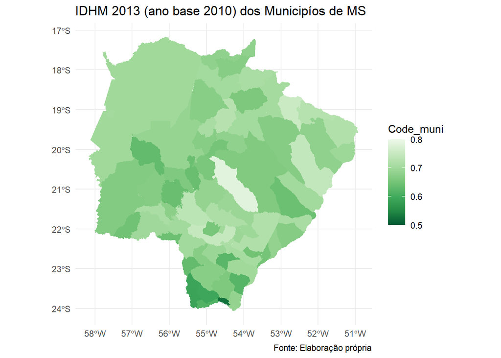

```r
ggplot() +
  geom_sf(data=dataset_final, aes(fill=IDHM), color= NA, size=.15)+
  labs(title="IDHM 2013 (ano base 2010) dos Municipíos de MS",
       caption='Fonte: Elaboração própria', size=8)+
  scale_fill_distiller(palette = "Greens", limits=c(0.5, 0.8),
                       name="Code_muni")+
  theme_minimal()
```

## Um mapa do IDHM Educacional de São Paulo

Como já lemos a tabela bruta dos dados, podemos filtrar os resultados para o estado de São Paulo agora

```r
dados_sp <- subset(atlas2013_dadosbrutos_pt, UF =='35' & ANO == '2010',
                   select = c(Codmun7, IDHM, IDHM_E, IDHM_L, IDHM_R))
print(dados_sp)
```

```
## # A tibble: 645 × 5
##    Codmun7  IDHM IDHM_E IDHM_L IDHM_R
##      <dbl> <dbl>  <dbl>  <dbl>  <dbl>
##  1 3500105 0.79   0.75   0.852  0.772
##  2 3500204 0.73   0.648  0.844  0.71
##  3 3500303 0.715  0.606  0.858  0.703
##  4 3500402 0.781  0.716  0.886  0.75
##  5 3500501 0.745  0.675  0.846  0.725
##  6 3500550 0.757  0.695  0.84   0.744
##  7 3500600 0.854  0.825  0.89   0.849
##  8 3500709 0.745  0.694  0.845  0.705
##  9 3500758 0.712  0.658  0.805  0.682
## 10 3500808 0.741  0.71   0.84   0.682
## # ℹ 635 more rows
```

Agora, vamos selecionar a esturuta de 2010 para compatibilizar o mapa de SP a partir da biblioteca `geobr`

```r
all_mun_sp <- read_municipality(code_muni = 35, year = 2010)
```

```
## Using year 2010
```

[output not shown]

[output cut: 158 more lines]

[output not shown]

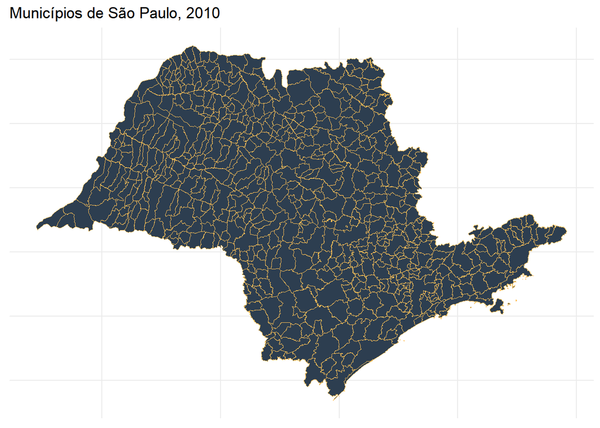

```r
# plot
ggplot() +
  geom_sf(data=all_mun_sp, fill="#2D3E50", color="#FEBF57", size=.15, show.legend = FALSE) +
  labs(title="Municípios de São Paulo, 2010", size=12) +
  theme_minimal() +
  no_axis
```

Justando os dados pela condição de que o `code_muni` do objeto `all_mun_sp` é igual ao `Codmun7` do objeto `dados_sp`

```r
dataset_final_sp = left_join(all_mun_sp, dados_sp, by = c("code_muni" = "Codmun7"))
```

Plotando o gráfico

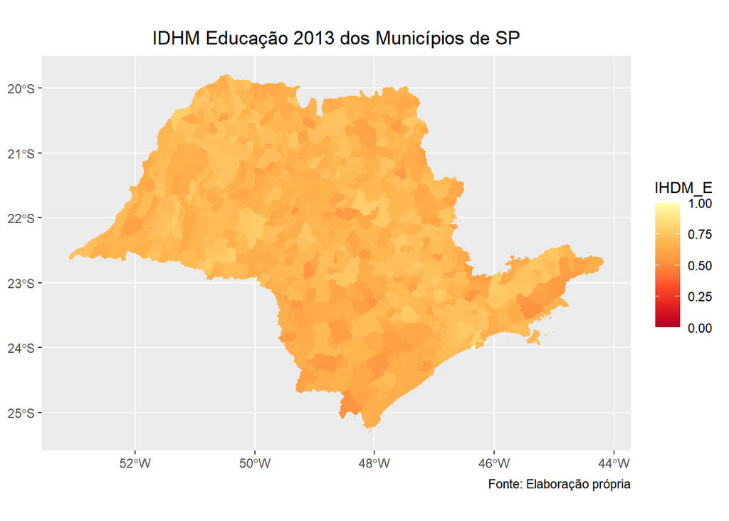

```r
ggplot()+
  geom_sf(data = dataset_final_sp, aes(fill = IDHM_E), color = NA, size = .15)+
  labs(title = "IDHM Educação 2013 dos Municípios de SP",
       caption = "Fonte: Elaboração própria", size = 8)+
  scale_fill_distiller(palette = "YlOrRd", limits = c(0.0, 1.0),
                       name="IHDM_E")+
  theme(plot.title = element_text(hjust = 0.5))
```